# Income Inequality vs Index of Health and Social Problems

coop711

2016-10-07

### Data Reading

Equality Trust에서 기부금을 받고 제공하는 두 종류의 자료 중 23개 국가의 각종 지표를 비교한 자료에 World Bank에서 발표하는 GDP자료를 추가한 자료를 data 단계에서 읽어들이고 필요한 부분만 정리한 `RData`파일을 읽어들이면,

```r
library(knitr)
load("Inequality_Index_HS.RData")
# data.full <- read.csv("../data/international-inequality_GDP.csv", stringsAsFactors = FALSE)
# data.full <- read.csv("../data/international-inequality_GDP.csv", stringsAsFactors = TRUE)
str(data.full)
```

```
## 'data.frame':    23 obs. of  30 variables:
##  $ Country                          : chr  "Australia" "Austria" "Belgium" "Canada" ...
##  $ Income.inequality                : num  7 4.82 4.6 5.63 4.3 3.72 5.6 5.2 6.2 6.05 ...
##  $ Trust                            : num  39.9 33.9 30.7 38.8 66.5 58 22.2 34.8 23.7 35.2 ...
##  $ Life.expectancy                  : num  79.2 78.5 78.8 79.3 76.6 78 79 78.3 78.3 77 ...
##  $ Infant.mortality                 : num  4.9 4.8 5 5.3 5.3 3.7 4.4 4.4 5 5.9 ...
##  $ Obesity                          : num  18.4 14.5 13.5 12.8 15 ...
##  $ Mental.illness                   : num  23 NA 12 19.9 NA NA 18.4 9.1 NA NA ...
##  $ Maths.and.literacy.scores        : num  524 498 518 530 503 ...
##  $ Teenage.births                   : num  18.4 14 9.9 20.2 8.1 9.2 9.3 13.1 11.8 18.7 ...
##  $ Homicides                        : num  16.9 11.6 13 17.3 12.7 28.2 21.5 13.7 13.9 8.6 ...
##  $ Imprisonment..log.               : num  4.61 4.52 4.28 4.77 4.17 4.11 4.5 4.51 3.33 4.17 ...
##  $ Social.mobility                  : num  NA NA NA 0.14 0.14 0.15 NA 0.17 NA NA ...
##  $ Index.of.health...social_problems: num  0.07 0.01 -0.23 -0.07 -0.19 -0.43 0.05 -0.06 0.38 0.25 ...
##  $ Child.overweight                 : num  NA 11.9 10.4 19.5 10.3 13.3 11.2 11.3 16 12.1 ...
```

[output cut: 16 more lines]

```r
str(data.21)
```

```
## 'data.frame':    21 obs. of  4 variables:
##  $ Country          : chr  "Australia" "Austria" "Belgium" "Canada" ...
##  $ Income.inequality: num  7 4.82 4.6 5.63 4.3 3.72 5.6 5.2 6.2 6.05 ...
##  $ Index.HS         : num  0.07 0.01 -0.23 -0.07 -0.19 -0.43 0.05 -0.06 0.38 0.25 ...
##  $ GDP_WB           : int  45926 47682 43435 45066 45537 40676 39328 46401 26851 49393 ...
```

### Barplots for Income Inequalities

```r
# par(mai = c(2.0, 0.8, 0.8, 0.4) + 0.2)
(fifth <- data.21$Income.inequality)
```

```
##  [1] 7.00 4.82 4.60 5.63 4.30 3.72 5.60 5.20 6.20 6.05 6.65 3.40 5.30 6.80
## [15] 3.85 8.00 5.55 3.95 5.73 7.17 8.55
```

```r
# barplot(fifth, names)
(Country <- data.21$Country)
```

```
##  [1] "Australia"   "Austria"     "Belgium"     "Canada"      "Denmark"
##  [6] "Finland"     "France"      "Germany"     "Greece"      "Ireland"
## [11] "Italy"       "Japan"       "Netherlands" "New Zealand" "Norway"
## [16] "Portugal"    "Spain"       "Sweden"      "Switzerland" "UK"
## [21] "USA"
```

```r
# barplot(fifth, names.arg = Country)
(o.fifth <- order(fifth))
```

```
##  [1] 12  6 15 18  5  3  2  8 13 17  7  4 19 10  9 11 14  1 20 16 21
```

```r
data.frame(Country, fifth, o.fifth, fifth[o.fifth], Country[o.fifth])
```

```
##        Country fifth o.fifth fifth.o.fifth. Country.o.fifth.
## 1    Australia  7.00      12           3.40            Japan
## 2      Austria  4.82       6           3.72          Finland
## 3      Belgium  4.60      15           3.85           Norway
## 4       Canada  5.63      18           3.95           Sweden
## 5      Denmark  4.30       5           4.30          Denmark
## 6      Finland  3.72       3           4.60          Belgium
## 7       France  5.60       2           4.82          Austria
## 8      Germany  5.20       8           5.20          Germany
## 9       Greece  6.20      13           5.30      Netherlands
## 10     Ireland  6.05      17           5.55            Spain
## 11       Italy  6.65       7           5.60           France
## 12       Japan  3.40       4           5.63           Canada
## 13 Netherlands  5.30      19           5.73      Switzerland
## 14 New Zealand  6.80      10           6.05          Ireland
## 15      Norway  3.85       9           6.20           Greece
## 16    Portugal  8.00      11           6.65            Italy
## 17       Spain  5.55      14           6.80      New Zealand
## 18      Sweden  3.95       1           7.00        Australia
## 19 Switzerland  5.73      20           7.17               UK
## 20          UK  7.17      16           8.00         Portugal
## 21         USA  8.55      21           8.55              USA
```

```r
ro.fifth <- order(fifth, decreasing = TRUE)
data.frame(Country, fifth, o.fifth, ro.fifth, fifth[ro.fifth], Country[ro.fifth])
```

```
##        Country fifth o.fifth ro.fifth fifth.ro.fifth. Country.ro.fifth.
## 1    Australia  7.00      12       21            8.55               USA
## 2      Austria  4.82       6       16            8.00          Portugal
## 3      Belgium  4.60      15       20            7.17                UK
## 4       Canada  5.63      18        1            7.00         Australia
## 5      Denmark  4.30       5       14            6.80       New Zealand
## 6      Finland  3.72       3       11            6.65             Italy
## 7       France  5.60       2        9            6.20            Greece
## 8      Germany  5.20       8       10            6.05           Ireland
## 9       Greece  6.20      13       19            5.73       Switzerland
## 10     Ireland  6.05      17        4            5.63            Canada
## 11       Italy  6.65       7        7            5.60            France
## 12       Japan  3.40       4       17            5.55             Spain
## 13 Netherlands  5.30      19       13            5.30       Netherlands
## 14 New Zealand  6.80      10        8            5.20           Germany
## 15      Norway  3.85       9        2            4.82           Austria
## 16    Portugal  8.00      11        3            4.60           Belgium
## 17       Spain  5.55      14        5            4.30           Denmark
## 18      Sweden  3.95       1       18            3.95            Sweden
## 19 Switzerland  5.73      20       15            3.85            Norway
## 20          UK  7.17      16        6            3.72           Finland
## 21         USA  8.55      21       12            3.40             Japan
```

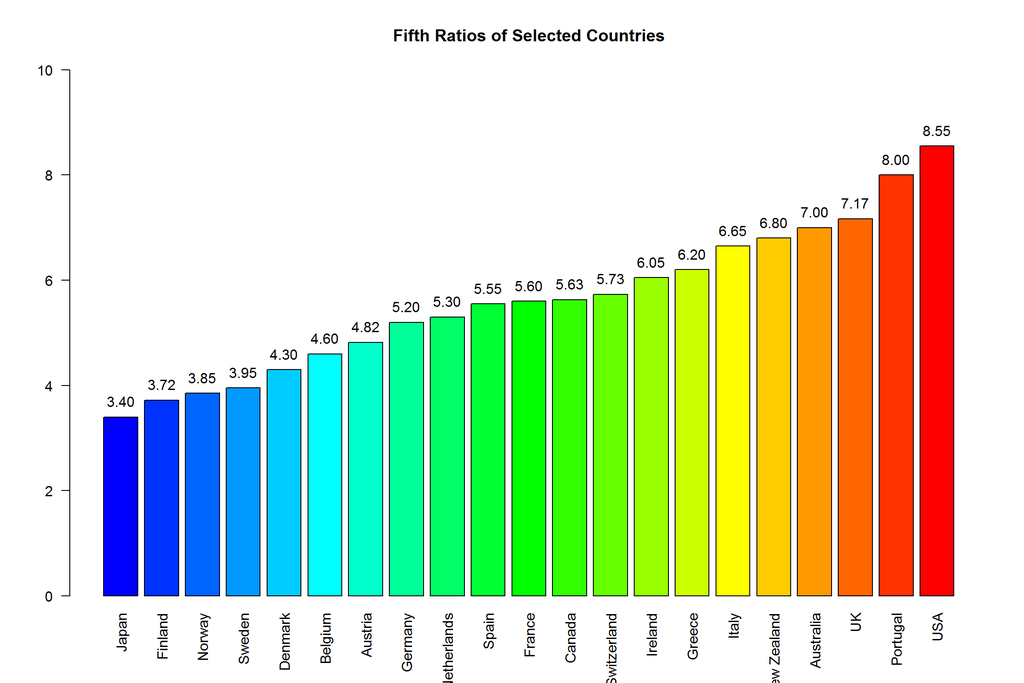

```r
# barplot(fifth[o.fifth])
# barplot(fifth[o.fifth], names.arg = Country[o.fifth])
# barplot(fifth[o.fifth], names.arg = Country[o.fifth],  col = rev(rainbow(nrow(data.21), start = 0, end = 2/3)))
# barplot(fifth[o.fifth], names.arg = Country[o.fifth],  col = rev(rainbow(nrow(data.21), start = 0, end = 2/3)), las = 2)
b.fifth <- barplot(fifth[o.fifth], names.arg = Country[o.fifth], col = rev(rainbow(nrow(data.21), start = 0, end = 2/3)), ylim = c(0, 10), xpd = FALSE, las = 2)
text(x = b.fifth, y = fifth[o.fifth] + 0.3, labels = format(fifth[o.fifth], digits = 3))
# text(x = b.fifth, y = fifth[o.fifth], labels = format(fifth[o.fifth], digits = 3))
# text(x = b.fifth[c(1, 11, 21)], y = fifth[o.fifth][c(1, 11, 21)] + 0.3, labels = format(fifth[o.fifth][c(1, 11, 21)], digits = 3))
title(main = "Fifth Ratios of Selected Countries")
```

### Scatter Diagram

우선 소득불평등과 건강 및 사회문제 지표의 관계를 대략적으로 살펴보면,

```r
Index_inequality.df <- data.21[c("Income.inequality", "Index.HS")]
str(Index_inequality.df)
```

```
## 'data.frame':    21 obs. of  2 variables:
##  $ Income.inequality: num  7 4.82 4.6 5.63 4.3 3.72 5.6 5.2 6.2 6.05 ...
##  $ Index.HS         : num  0.07 0.01 -0.23 -0.07 -0.19 -0.43 0.05 -0.06 0.38 0.25 ...
```

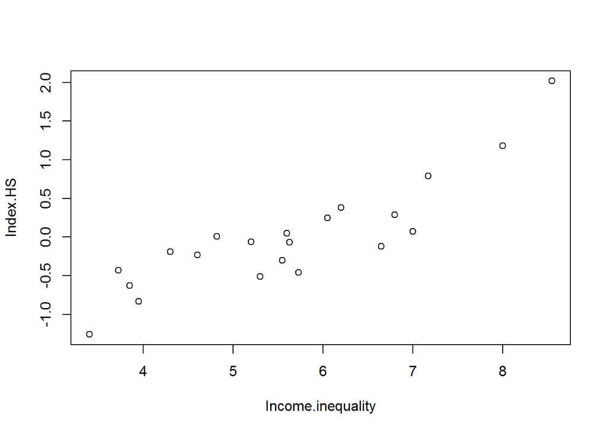

```r
plot(Index_inequality.df)
```

```r
cor.1 <- cor(data.21["Income.inequality"], data.21["Index.HS"])
cor.1
```

```
##                    Index.HS
## Income.inequality 0.8735785
```

매우 높은 양의 상관관계(r = 0.8735785) 가 관찰됨을 알 수 있다. 자주 사용하는 `data.21[c("Income.inequality", "Index.HS")]`를 간단한 R 오브젝트로 assign하여 반복 사용하고 있다. `cor()`에도 data frame을 사용하면 어떻게 되는지 다음 결과와 비교해 보자.

```r
cor(Index_inequality.df)
```

```
##                   Income.inequality  Index.HS
## Income.inequality         1.0000000 0.8735785
## Index.HS                  0.8735785 1.0000000
```

각 점이 어느 나라를 나타내는지 표시하기 위하여 `text()` 를 활용하자. 동그라미 대신 까만 점으로 표시하고, 나라 이름을 올려보자.

```r
(Country <- data.21[, "Country"])
```

```
##  [1] "Australia"   "Austria"     "Belgium"     "Canada"      "Denmark"
##  [6] "Finland"     "France"      "Germany"     "Greece"      "Ireland"
## [11] "Italy"       "Japan"       "Netherlands" "New Zealand" "Norway"
## [16] "Portugal"    "Spain"       "Sweden"      "Switzerland" "UK"
## [21] "USA"
```

```r
(Country.2 <- data.21["Country"])
```

```
##        Country
## 1    Australia
## 2      Austria
## 3      Belgium
## 4       Canada
## 5      Denmark
## 6      Finland
## 7       France
## 8      Germany
## 9       Greece
## 10     Ireland
## 12       Italy
## 13       Japan
## 14 Netherlands
## 15 New Zealand
## 16      Norway
## 17    Portugal
## 19       Spain
## 20      Sweden
## 21 Switzerland
## 22          UK
## 23         USA
```

```r
(Country.3 <- data.21["Country"]$Country)
```

```
##  [1] "Australia"   "Austria"     "Belgium"     "Canada"      "Denmark"
##  [6] "Finland"     "France"      "Germany"     "Greece"      "Ireland"
## [11] "Italy"       "Japan"       "Netherlands" "New Zealand" "Norway"
## [16] "Portugal"    "Spain"       "Sweden"      "Switzerland" "UK"
## [21] "USA"
```

```r
str(Country)
```

```
##  chr [1:21] "Australia" "Austria" "Belgium" "Canada" ...
```

```r
str(Country.2)
```

```
## 'data.frame':    21 obs. of  1 variable:
##  $ Country: chr  "Australia" "Austria" "Belgium" "Canada" ...
```

```r
str(Country.3)
```

```
##  chr [1:21] "Australia" "Austria" "Belgium" "Canada" ...
```

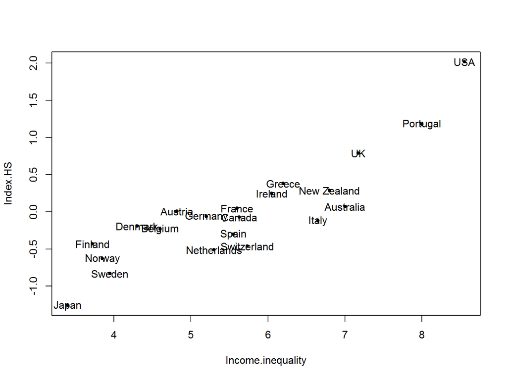

```r
plot(Index_inequality.df, pch = 20)
text(Index_inequality.df, labels = Country)
```

text label의 위치 기본값은 바로 점 위임을 알 수 있다. 위치 선정에 가능한 값들을 넣어보자.

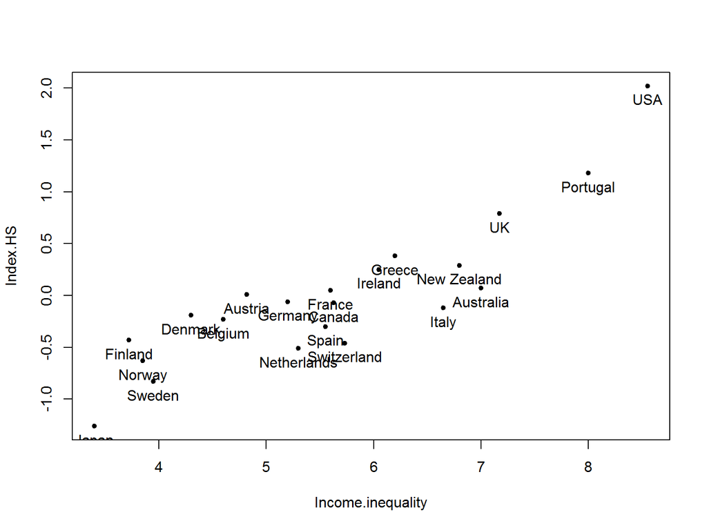

```r
plot(Index_inequality.df, pch = 20)
text(Index_inequality.df, labels = Country, pos = 1)
```

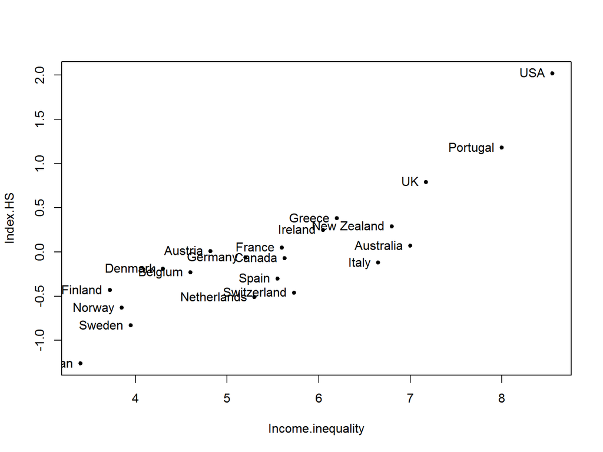

```r
plot(Index_inequality.df, pch = 20)
text(Index_inequality.df, labels = Country, pos = 2)
```

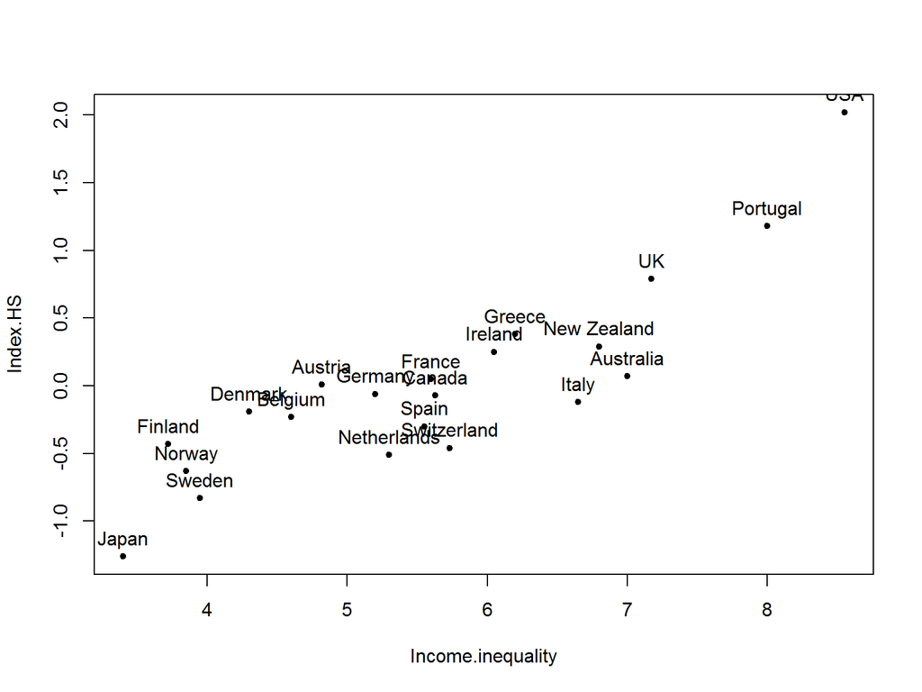

```r
plot(Index_inequality.df, pch = 20)
text(Index_inequality.df, labels = Country, pos = 3)
```

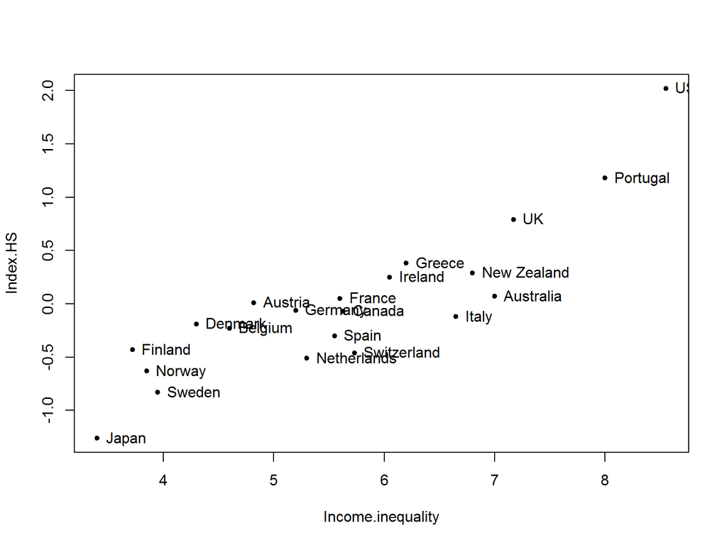

```r
plot(Index_inequality.df, pch = 20)
text(Index_inequality.df, labels = Country, pos = 4)
```

우선 x-축과 y-축의 범위를 `xlim = c(3, 9), ylim = c(-1.5, 2.5)`로 하여 미국과 일본의 라벨이 도표 밖으로 나가지 않게 하자. `pos = 4`로 하고 `cex = 0.8`로 하여 글자 크기를 줄여보면,

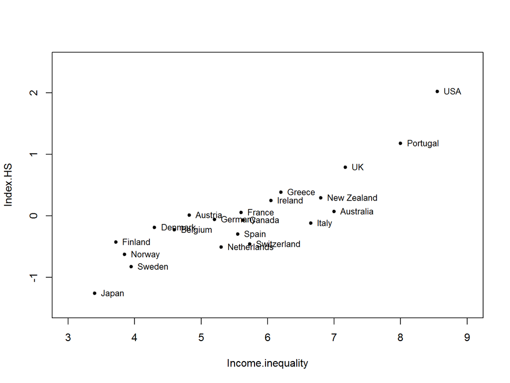

```r
plot(Index_inequality.df, pch = 20, xlim = c(3, 9), ylim = c(-1.5, 2.5))
text(Index_inequality.df, labels = Country, pos = 4, cex = 0.8)
```

오스트리아, 덴마크, 독일, 네덜란드의 라벨만 점 왼편에 위치시켜 보자. 각 인덱스를 찾아보면,

```r
which(Country %in% c("Austria", "Denmark", "Germany", "Netherlands"))
```

```
## [1]  2  5  8 13
```

```r
text.left <- which(Country %in% c("Austria", "Denmark", "Germany", "Netherlands"))
text.left
```

```
## [1]  2  5  8 13
```

```r
text.right <- setdiff(1:nrow(data.21), text.left)
text.right
```

```
##  [1]  1  3  4  6  7  9 10 11 12 14 15 16 17 18 19 20 21
```

```r
pos.text <- ifelse(1:nrow(data.21) %in% text.left, 2, 4)
```

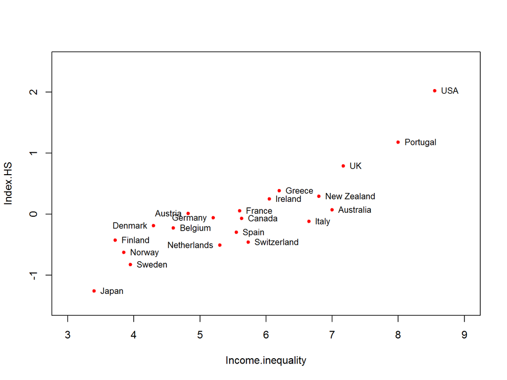

```r
plot(Index_inequality.df, pch = 20, col = "red", xlim = c(3, 9), ylim = c(-1.5, 2.5))
text(Index_inequality.df, labels = Country, pos = pos.text, cex = 0.8)
```

독일의 라벨을 위로 붙이면 보기가 나아질 것으로 생각되므로,

```r
which(Country %in% "Germany")
```

```
## [1] 8
```

```r
text.up <- which(Country %in% "Germany")
text.up
```

```
## [1] 8
```

```r
text.left <- setdiff(1:nrow(data.21), c(text.right, text.up))
text.left
```

```
## [1]  2  5 13
```

```r
pos.text <- ifelse(1:nrow(data.21) %in% text.up, 3, ifelse(1:nrow(data.21) %in% text.left, 2, 4))
pos.text
```

```
##  [1] 4 2 4 4 2 4 4 3 4 4 4 4 2 4 4 4 4 4 4 4 4
```

이제 조정된 text 외에 x-축과 y-축에 적절한 라벨과 메인 타이틀을 넣어보자.

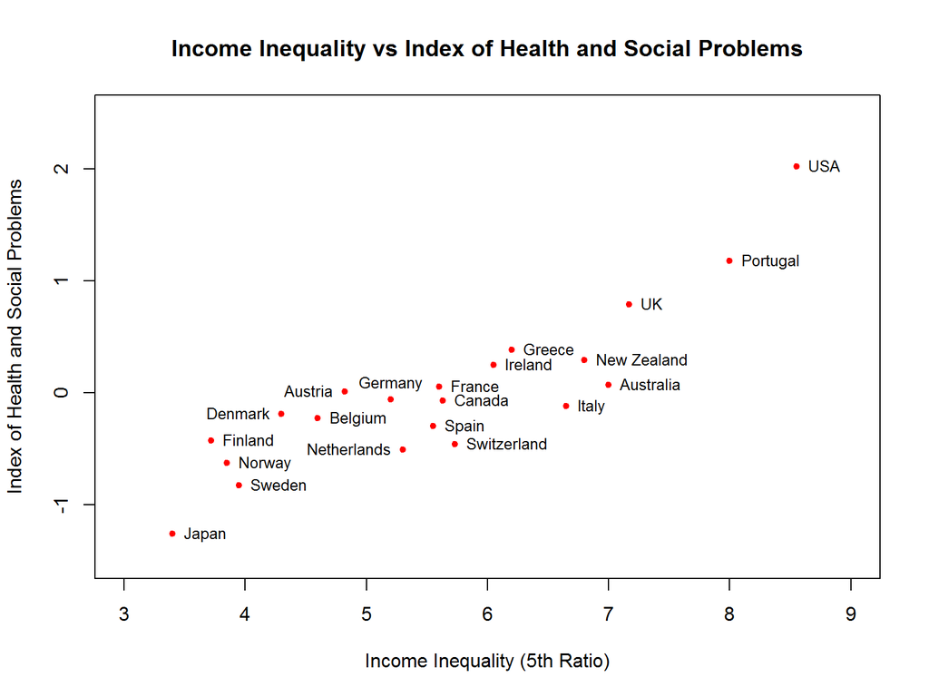

```r
plot(Index_inequality.df, pch = 20, col = "red", xlim = c(3, 9), ylim = c(-1.5, 2.5), ann = FALSE)
text(Index_inequality.df, labels = Country, pos = pos.text, cex = 0.8)
main.title <- "Income Inequality vs Index of Health and Social Problems"
x.lab <- "Income Inequality (5th Ratio)"
y.lab <- "Index of Health and Social Problems"
title(main = main.title, xlab = x.lab, ylab = y.lab)
```

건강 및 사회문제 지표의 경우 어느 방향이 좋은지 알 수 없으므로 친절하게 도표의 주변에(margin)에 알려주려면,

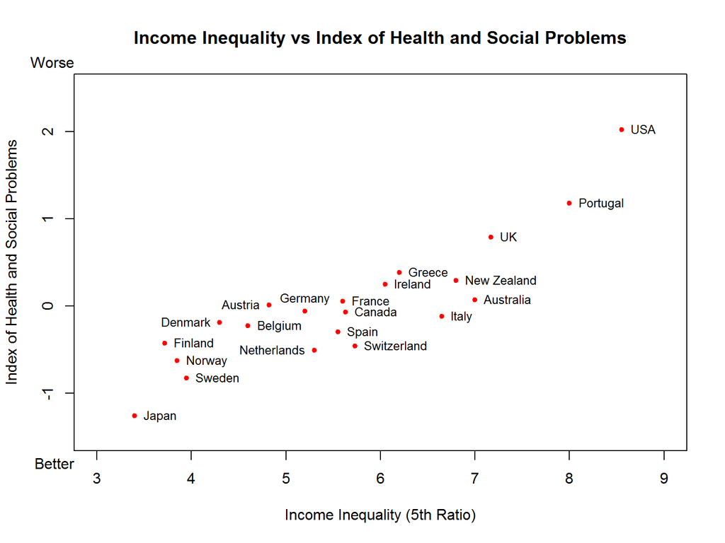

```r
plot(Index_inequality.df, pch = 20, col = "red", xlim = c(3, 9), ylim = c(-1.5, 2.5), ann = FALSE)
text(Index_inequality.df, labels = Country, pos = pos.text, cex = 0.8)
main.title <- "Income Inequality vs Index of Health and Social Problems"
x.lab <- "Income Inequality (5th Ratio)"
y.lab <- "Index of Health and Social Problems"
title(main = main.title, xlab = x.lab, ylab = y.lab)
mtext(c("Better", "Worse"), side = 2, at = c(-1.8, 2.8), las = 1)
```

상관계수를 텍스트로 그림 안에 넣어주고 여기까지 작업한 내용을 별도의 파일로 저장해 놓으려면,

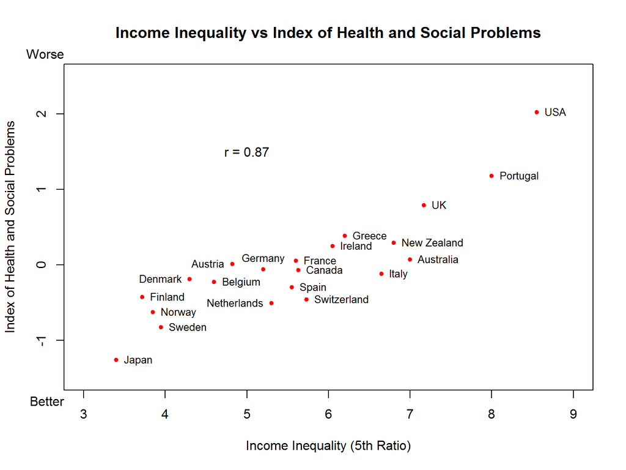

```r
plot(Index_inequality.df, pch = 20, col = "red", xlim = c(3, 9), ylim = c(-1.5, 2.5), ann = FALSE)
text(Index_inequality.df, labels = Country, pos = pos.text, cex = 0.8)
main.title <- "Income Inequality vs Index of Health and Social Problems"
x.lab <- "Income Inequality (5th Ratio)"
y.lab <- "Index of Health and Social Problems"
title(main = main.title, xlab = x.lab, ylab = y.lab)
mtext(c("Better", "Worse"), side = 2, at = c(-1.8, 2.8), las = 1)
text(x = 5, y = 1.5, labels = paste("r =", round(cor.1, digits = 2)))
```

```r
# dev.copy(png, file = "../pics/inequality_health_social_en_72dpi.png", width = 640, height = 480)
# dev.off()
```

선형회귀선을 추가하여 대체적인 추세를 보려면 `lm()`을 이용하되, `x`, `y`의 순서를 제대로 바꿔야 함에 유의.

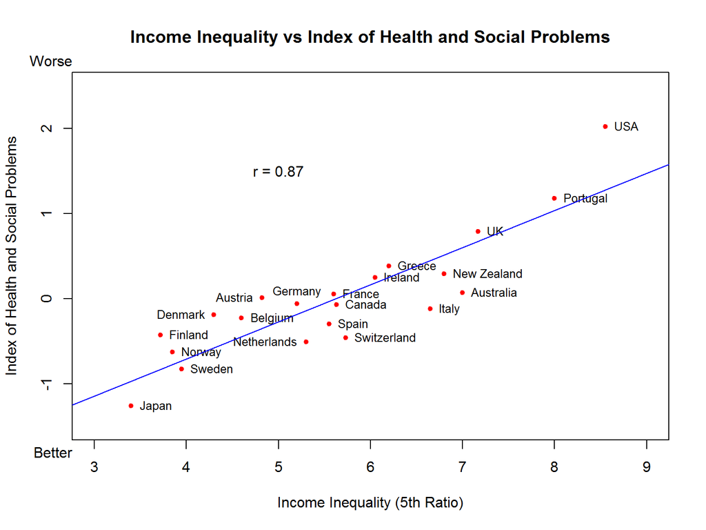

```r
plot(Index_inequality.df, pch = 20, col = "red", xlim = c(3, 9), ylim = c(-1.5, 2.5), ann = FALSE)
text(Index_inequality.df, labels = Country, pos = pos.text, cex = 0.8)
main.title <- "Income Inequality vs Index of Health and Social Problems"
x.lab <- "Income Inequality (5th Ratio)"
y.lab <- "Index of Health and Social Problems"
title(main = main.title, xlab = x.lab, ylab = y.lab)
mtext(c("Better", "Worse"), side = 2, at = c(-1.8, 2.8), las = 1)
text(x = 5, y = 1.5, labels = paste("r =", round(cor.1, digits = 2)))
lm.ineq <- lm(Index.HS ~ Income.inequality, data = Index_inequality.df)
# lm.ineq <- lm(Index_inequality.df[2:1])
abline(lm.ineq$coef, col = "blue")
```

GDP와 건강 및 사회문제 지수

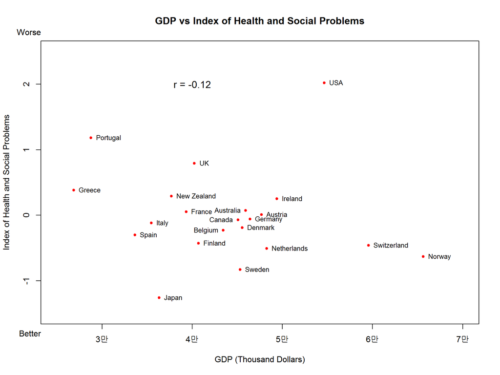

```r
Index_GDP.df <- data.21[c("GDP_WB", "Index.HS")]
text.left.2 <- which(Country %in% c("Canada", "Belgium", "Australia"))
text.right.2 <- setdiff(1:nrow(data.21), c(text.left.2))
pos.text.2 <- ifelse(1:nrow(data.21) %in% text.left.2, 2, 4)
plot(Index_GDP.df, pch = 20, col = "red", xlim = c(25000, 70000), ylim = c(-1.5, 2.5), xaxt = "n", ann = FALSE)
axis(side = 1, at = seq(30000, 70000, by = 10000), labels = paste(3:7, "만", sep = ""))
text(Index_GDP.df, labels = Country, pos = pos.text.2, cex = 0.8)
cor.2 <- cor(Index_GDP.df["GDP_WB"], Index_GDP.df["Index.HS"])
text(x = 40000, y = 2, labels = paste("r =", round(cor.2, digits = 2)), cex = 1.2)
main.title.2 <- "GDP vs Index of Health and Social Problems"
x.lab.2 <- "GDP (Thousand Dollars)"
y.lab.2 <- "Index of Health and Social Problems"
title(main = main.title.2, xlab = x.lab.2, ylab = y.lab.2)
mtext(c("Better", "Worse"), side = 2, at = c(-1.8, 2.8), las = 1)
```

```r
# dev.copy(png, file = "../pics/GDP_health_social_en_72dpi.png", width = 640, height = 480)
# dev.off()
```

### 한글화

국가명을 한글로 만들어 `Country.kr`로 저장하자.

```r
Country.kr<-c("호주", "오스트리아", "벨기에", "캐나다", "덴마크",
"핀란드", "프랑스", "독일", "그리스", "아일랜드", "이탈리아",
"일본", "네덜란드", "뉴질랜드", "노르웨이", "포르투갈",
"스페인", "스웨덴", "스위스", "영국", "미국")
```

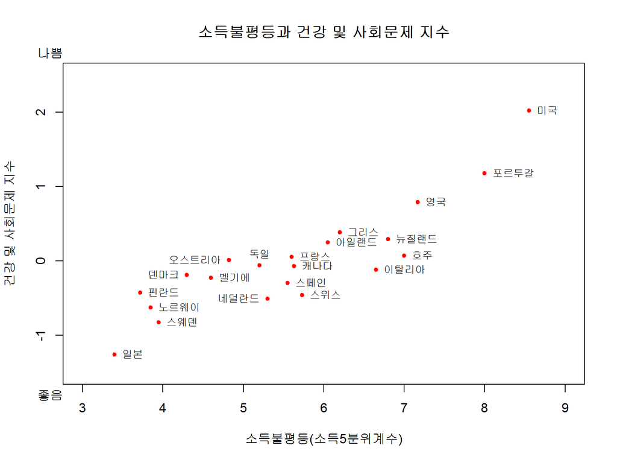

```r
# library(extrafont)
# par(family = "HCR Dotum LVT")
plot(Index_inequality.df, pch = 20, col = "red", xlim = c(3, 9), ylim = c(-1.5, 2.5), ann = FALSE)
text(Index_inequality.df[text.right, ], labels = Country.kr[text.right], pos = 4, cex = 0.8)
text(Index_inequality.df[text.left, ], labels = Country.kr[text.left], pos = 2, cex = 0.8)
text(Index_inequality.df[text.up, ], labels = Country.kr[text.up], pos = 3, cex = 0.8)
main.title.kr <- "소득불평등과 건강 및 사회문제 지수"
x.lab.kr <- "소득불평등(소득5분위계수)"
y.lab.kr <- "건강 및 사회문제 지수"
title(main = main.title.kr, xlab = x.lab.kr, ylab = y.lab.kr)
mtext(c("좋음", "나쁨"), side = 2, at = c(-1.8, 2.8), las = 1)
```

상관계수 r = 0.87 를 도표 안에 표시하고 별도의 파일로 출력하려면,

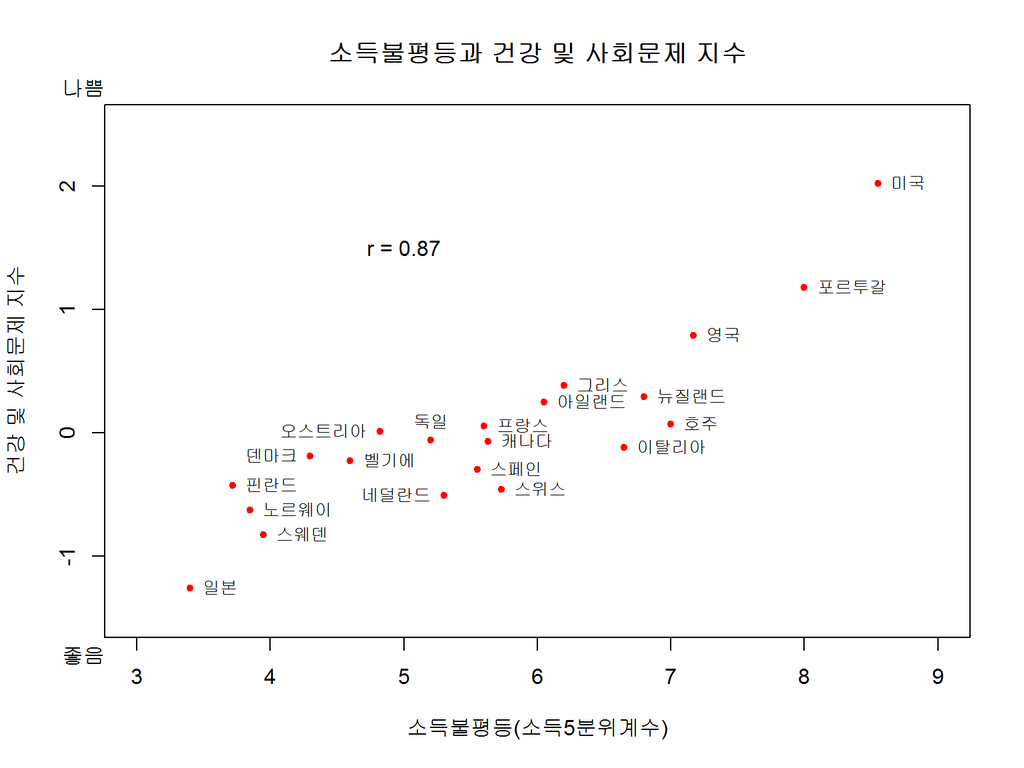

```r
# par(family = "HCR Dotum LVT")
plot(Index_inequality.df, pch = 20, col = "red", xlim = c(3, 9), ylim = c(-1.5, 2.5), ann = FALSE)
text(Index_inequality.df, labels = Country.kr, pos = pos.text, cex = 0.8)
main.title.kr <- "소득불평등과 건강 및 사회문제 지수"
x.lab.kr <- "소득불평등(소득5분위계수)"
y.lab.kr <- "건강 및 사회문제 지수"
title(main = main.title.kr, xlab = x.lab.kr, ylab = y.lab.kr)
mtext(c("좋음", "나쁨"), side = 2, at = c(-1.8, 2.8), las = 1)
text(x = 5, y = 1.5, labels = paste("r =", round(cor(Index_inequality.df[1], Index_inequality.df[2]), digits = 2)))
```

```r
# dev.copy(png, file = "../pics/inequality_health_social_72dpi.png", width = 640, height = 480)
# dev.off()
```

선형회귀선을 이번에는 `lsfit`을 이용하여 삽입

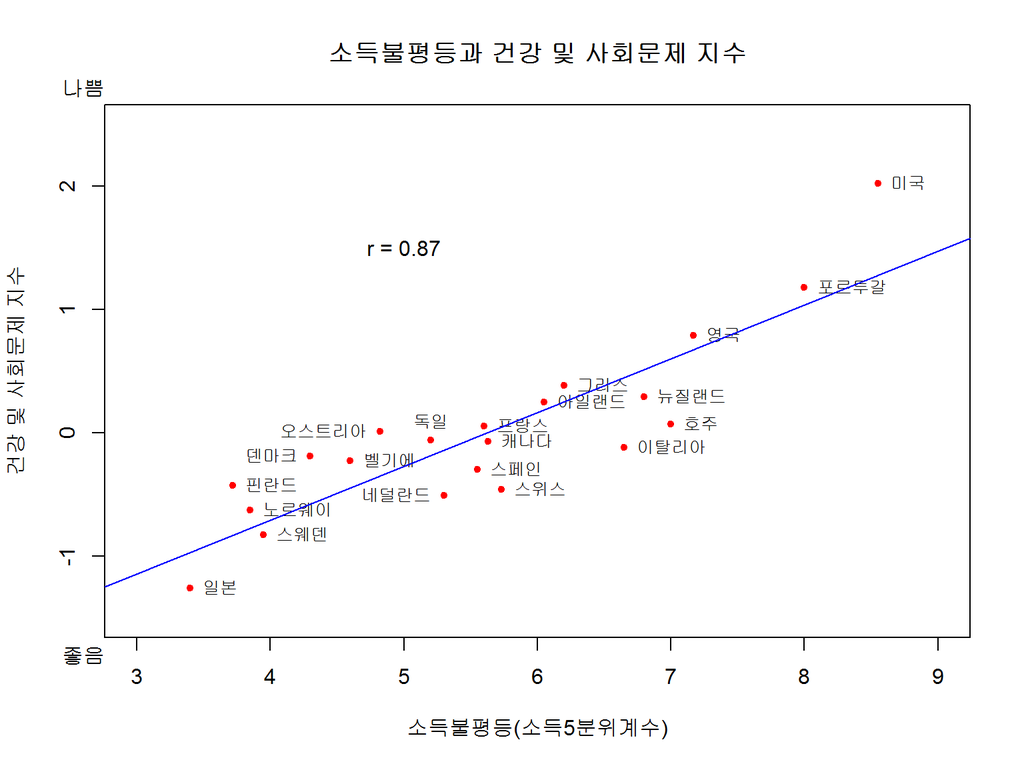

```r
# par(family = "HCR Dotum LVT")
plot(Index_inequality.df, pch = 20, col = "red", xlim = c(3, 9), ylim = c(-1.5, 2.5), ann = FALSE)
text(Index_inequality.df, labels = Country.kr, pos = pos.text, cex = 0.8)
main.title.kr <- "소득불평등과 건강 및 사회문제 지수"
x.lab.kr <- "소득불평등(소득5분위계수)"
y.lab.kr <- "건강 및 사회문제 지수"
title(main = main.title.kr, xlab = x.lab.kr, ylab = y.lab.kr)
mtext(c("좋음", "나쁨"), side = 2, at = c(-1.8, 2.8), las = 1)
text(x = 5, y = 1.5, labels = paste("r =", round(cor(Index_inequality.df[1], Index_inequality.df[2]), digits = 2)))
lsfit.ineq <- lsfit(x = Index_inequality.df[, 1], y = Index_inequality.df[, 2])
abline(lsfit.ineq$coefficients, col = "blue")
```

GDP와의 관계

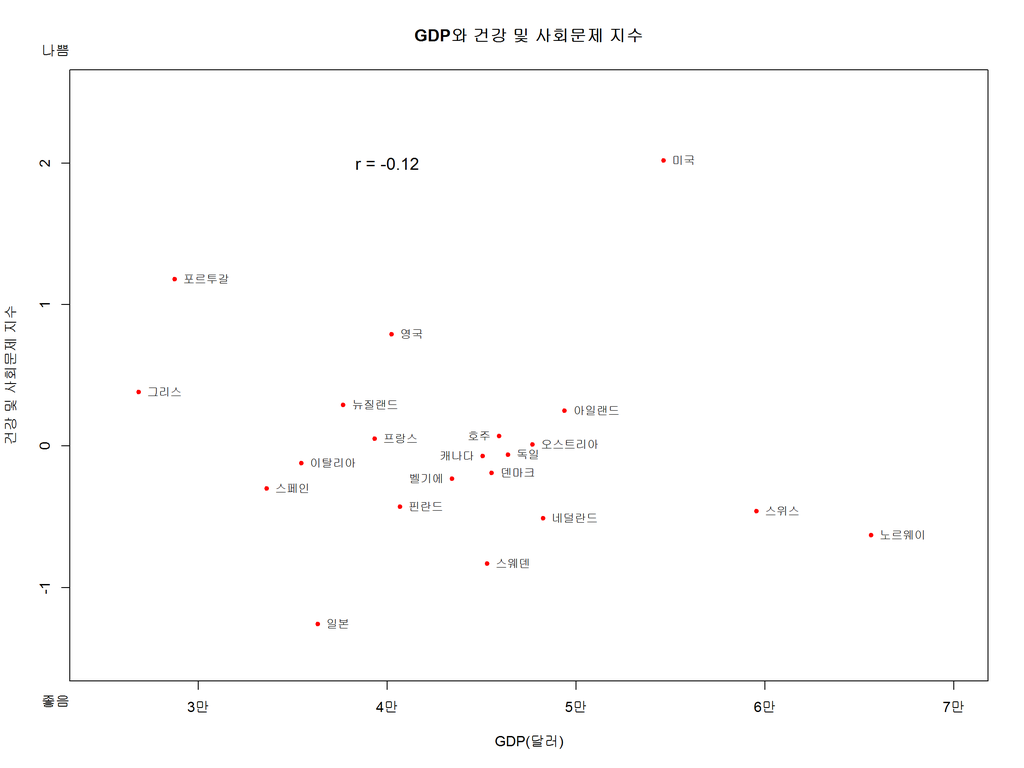

```r
# par(family = "HCR Dotum LVT")
Index_GDP.df <- data.21[c("GDP_WB", "Index.HS")]
text.left.2 <- which(Country %in% c("Canada", "Belgium", "Australia"))
text.right.2 <- setdiff(1:nrow(data.21), c(text.left.2))
pos.text.2 <- ifelse(1:nrow(data.21) %in% text.left.2, 2, 4)
plot(Index_GDP.df, pch = 20, col = "red", xlim = c(25000, 70000), ylim = c(-1.5, 2.5), xaxt = "n", ann = FALSE)
axis(side = 1, at = seq(30000, 70000, by = 10000), labels = paste(3:7, "만", sep = ""))
text(Index_GDP.df, labels = Country.kr, pos = pos.text.2, cex = 0.8)
text(x = 40000, y = 2, labels = paste("r =", round(cor(Index_GDP.df[1], Index_GDP.df[2]), digits = 2)), cex = 1.2)
main.title.2.kr <- "GDP와 건강 및 사회문제 지수"
x.lab.2.kr <- "GDP(달러)"
y.lab.2.kr <- "건강 및 사회문제 지수"
title(main = main.title.2.kr, xlab = x.lab.2.kr, ylab = y.lab.2.kr)
mtext(c("좋음", "나쁨"), side = 2, at = c(-1.8, 2.8), las = 1)
```

```r
# dev.copy(png, file = "../pics/GDP_health_social_72dpi.png", width = 640, height = 480)
# dev.off()
```